# Multi-cell analysis: LiFi 1.0 (LED) vs LiFi 2.0 (VCSEL)

This notebook extends the single-cell analysis to a multi-cell scenario: several access points (APs) sit on the ceiling, each creating its own cell, and the cells now interfere with each other.

**Methodology.** Section 2 fixes one shared scenario, channel model and receiver for both technologies, and adopts a beam-count standard for LiFi 2.0 that is justified in the single-cell notebook. Case 1 then compares coverage across a range of plausible services and fixes a single SINR threshold from that comparison, so that every case after it uses the same yardstick instead of an arbitrary one. Cases 2 to 4 and the cooperation section apply that same standard to four complementary questions (equal infrastructure, cross-equivalence, scalability, and what cooperation between APs can add), and Sections 8 to 9 bring all of them together into one synthesis.

Full citations for every paper referenced here are listed in `references.md` at the repository root (the PDFs themselves aren't redistributed here, for copyright reasons).

**Table of contents**

- 1. Introduction
- 2. System model
  - 2.1 Scenario and transmission models
  - 2.2 The eye-safety budget: consistent with the single-cell notebook
  - 2.3 Channel, association, SINR and capacity
  - 2.4 Implementation
  - 2.5 Directivity
  - 2.6 Metrics
  - 2.7 Traceability of every decision
- 3. Case 1: coverage across services
- 4. Case 2: equal infrastructure
- 5. Case 3: cross-equivalence
- 6. Case 4: scalability and densification
- 7. Cooperative networks
- 8. Results and discussion
  - 8.1 Everything on one map
  - 8.2 Discussion
- 9. Conclusions
- 10. Limitations
- 11. References

## 1. Introduction

|  | **LiFi 1.0 (LED)** | **LiFi 2.0 (VCSEL)** |
| --- | --- | --- |
| Bandwidth | 20 MHz: rate is capped no matter the power (`[RIS-VLC]` Table III) | 2 GHz (`[VCSEL-Precoding]` Table I); 18 GHz devices already exist (`[VCSEL-70Gbps]`) |
| Directivity | very low: a wide Lambertian lobe, good for lighting, but it gives energy into neighbouring cells | very high: a narrow Gaussian beam that does not reach the next cell |
| Power limit | fixed by the illumination requirement, a room-level constraint | fixed by eye safety, a per-source constraint in the milliwatt range |
| Architecture | one emitter per AP, the luminaire itself | dense arrays of emitters (`[VCSEL-Precoding]`: 4x4-8x8 at 10 um pitch) |

The single-cell notebook already showed neither technology works alone: one LED covers only its FoV disk (35% of the room), and one VCSEL covers almost nothing. So the real question is a network one, not a single-link one: how many APs, how much power, how much interference.

## 2. System model

### 2.1 Scenario and transmission models

The room is 5 x 5 x 3 m.

APs sit on the ceiling (height 3 m) in an N x N lattice. N = 2-4 is the main comparison range, generalizing the 2x2 benchmark of `[RIS-VLC]` into the natural design space for densification.

Users are a uniform grid of receivers on the desk plane (height 1 m, $\Delta z$ = 2 m below the ceiling), 200 x 200 points, all pointing straight up with no blockage. The receiver is identical for both technologies ($A_{PD}$ = 1 cm^2, FoV $\Psi_c$ = 40 deg, concentrator $n$ = 1.5), the same unification from the single-cell notebook, since the FoV belongs to the photodiode, not the source.

**LiFi 2.0: VCSEL AP.** Each AP is an array of $M = m \times m$ emitters, arranged in a grid across the AP's cell, with beam selection: only the emitter aimed closest to the user turns on. "Total beams" ($N_{AP}\times M^2$) is this technology's deployment-cost unit, the same role watts plays for LiFi 1.0: it is the count of individually-selectable emitters across the whole deployment, not a measure of power. Full precoding would need channel state information and multi-user scheduling, which is beyond what this comparison of transmitter architectures needs, so beam selection stands in as a simplified form of beam steering. It's conservative relative to `[VCSEL-Precoding]`'s own precoding, which has more degrees of freedom to exploit. $M=256$ (a 16x16 grid) is used throughout: the single-cell notebook's own beam-grid section (Section 6.2 there) shows mean rate climbing steeply up to that point and flattening out beyond it, for one cell in isolation, before this notebook's own Cases add interference and density on top (a simple, round number chosen for that reason, not for optimality).

A VCSEL is a coherent emitter (unlike an LED's incoherent spontaneous emission): that spatial coherence is exactly what gives it a narrow, well-defined Gaussian beam instead of a Lambertian glow. This notebook only uses that coherence for the *emission* itself: both technologies still use IM/DD (information carried in intensity), and no phase-based modulation or detection is assumed anywhere below. This also applies to Section 7's cooperative combining: APs there add optical *amplitudes* before square-law detection, which needs synchronized emission, not phase-coded data.

### 2.2 The eye-safety budget: consistent with the single-cell notebook

The VCSEL's per-emitter power is the same eye-safe ceiling derived in the single-cell notebook (Section 4.2): the `[Eye-Safety]` Algorithm 1 + eq. (36) methodology, at the same $w_0 = 5\ \mu m$ waist already justified there. Both notebooks compute it with the identical function, so the two are directly comparable.

- At this waist, the ceiling comes out to **2.49 mW per active emitter**. Beam selection only ever turns on one emitter at a time, so that emitter gets the full 2.49 mW: the array buys the ability to aim, not more power.
- `[VCSEL-70Gbps]` independently operates a real 940 nm VCSEL at about 5 mW, roughly 2x the computed ceiling.

`[Eye-Safety]` (Sec. III-C) classifies sources by their angular subtense ($\alpha_{min}$ = 1.5 mrad, $\alpha_{max}$ = 100 mrad, with the MPE (maximum permissible exposure) relaxed for extended sources via $C_6$). Applied here: APs sit metres apart, so each gets an independent eye-safety budget; emitters inside one AP sit only 10 um apart, so they share a single budget.

### 2.3 Channel, association, SINR and capacity

The channel models are the same ones validated in the single-cell notebook: the LED follows the Lambertian LOS model (`[RIS-VLC]` eq. (1)), and the VCSEL follows the Gaussian-beam model (`[VCSEL-Precoding]` eqs. (2)-(8)), with $r$ now the distance to that specific beam's axis. The FoV test still uses the angle to the AP itself, since that's where the light physically comes from. Both models are LOS only and share the same concentrator gain $G$ (`[VCSEL-Precoding]` eq. (8)).

Each user is associated with the AP giving the strongest received power, $s(\mathbf{u}) = \arg\max_i P_i H_i(\mathbf{u})$. This best-server rule is a standard cellular convention and it avoids pulling in scheduling algorithms that aren't the point of this comparison.

The SINR follows the structure of `[VCSEL-Precoding]` eq. (11):

$$\gamma = \frac{(\rho P_s H_s)^2}{N_0 B + \sum_{i\neq s}(\rho P_i H_i)^2}$$

Interference behaves very differently for the two technologies, even though both use the SINR expression above ($\gamma = S/(N+I)$):

- **LiFi 1.0:** every LED AP transmits continuously and its wide Lambertian lobe reaches well past its own cell, so a user usually picks up interfering power $H_i$ from several neighbouring APs at once. The interference term $\sum_{i\neq s}(\rho P_i H_i)^2$ just sums over every neighbour's Lambertian gain at the user.
- **LiFi 2.0:** there is interference here too, it just works differently. A neighbouring AP still has only one beam active at a time, but it is aimed wherever that AP's own user happens to be, and our user's position gives no information about where that is. So the exact interfering gain from any one neighbour cannot be computed without knowing its user's location too, which this notebook does not track. The modelling choice: assume users are spread uniformly within each cell, and use the average of that neighbour's Gaussian beam gain over all $M$ of its candidate aim points as its expected interfering contribution. That average comes out small, since most of those $M$ points sit far from our user, but it is a computed number, not an assumption that LiFi 2.0 has no interference to model.

The achievable rate uses the same IM/DD lower bound as the single-cell notebook, from `[Capacity-Bound]` and used by both reference papers: $R = \frac{B}{2}\log_2(1 + \frac{e}{2\pi}\gamma)$. Classical Shannon capacity doesn't apply here, since the transmitted signals are real and non-negative, not complex.

### 2.4 Implementation

The cell below builds the AP lattice, the VCSEL beam grid inside each AP, and the association/SINR/rate pipeline described above.

```python
import numpy as np
import matplotlib.pyplot as plt
import pandas as pd
from matplotlib.patches import Patch

# scenario setup
ROOM = 5.0; AREA = ROOM**2
dz = 3.0 - 1.0 # AP 3 m, receiver 1 m  - [RIS-VLC] Table III

# same receiver settings as the single-cell notebook
APD = 1e-4 # [RIS-VLC] Table III = [VCSEL-Precoding] Table I
RHO = 1.0 # same in both papers
PSI_C = np.deg2rad(40.0) # [RIS-VLC] Table III
G_CONC = 1.5**2 / np.sin(PSI_C)**2 # [VCSEL-Precoding] eq. (8)
R_FOV = dz * np.tan(PSI_C) # FoV footprint radius on the desk plane

# transmitters (access points)
M_LED = -1.0 / np.log2(np.cos(np.deg2rad(80.0))) # Lambertian order - [RIS-VLC] eq. (1), Table III
LAMBDA = 950e-9 # [VCSEL-Precoding] Table I
W0 = 5e-6 # [Eye-Safety] Figs. 7,9,13,16-18  (see Sec. 2.2)

# max safe power per laser, calculated the same way as in the single-cell notebook
def mpe_point_long_exposure(lam_nm):
    C4 = 10**(0.002 * (lam_nm - 700))
    C7 = 1.0 if lam_nm < 1150 else 10**(0.018 * (lam_nm - 1150))
    return 10 * C4 * C7 # MPE [W/m^2], [Eye-Safety] Table 4

def eye_safe_ptx(w0, lam, rp=3.5e-3):
    zR_ = np.pi * w0**2 / lam
    theta_div = lam / (np.pi * w0)
    d86 = (np.pi * w0 / lam) * np.sqrt(-2 * rp**2 / np.log(1 - 0.86))
    if 2 * theta_div > 0.092 and d86 < 0.1:
        zhaz = 0.1
    else:
        alpha = 2 * np.arctan(w0 / d86)
        zhaz = 2 * w0 / 0.0021 if alpha < 1.5e-3 else 9.2 * np.pi * w0 / (2 * lam)
    Wzhaz = w0 * np.sqrt(1 + (zhaz / zR_)**2)
    eta = 1 - np.exp(-2 * rp**2 / Wzhaz**2)
    return (1 / eta) * mpe_point_long_exposure(lam * 1e9) * np.pi * rp**2, zhaz, eta

P_VCSEL, _, _ = eye_safe_ptx(W0, LAMBDA) # [Eye-Safety] Algorithm 1 + eq. (36), same as single-cell Sec. 4.2

# how the signal travels from transmitter to receiver
N0 = 2.5e-20 # [RIS-VLC] Table III
B_LED, B_VCSEL = 20e6, 2e9 # [RIS-VLC] Table III / [VCSEL-Precoding] Table I
K_BOUND = np.e / (2*np.pi) # [Capacity-Bound]
KE_V = 280.0 # [RIS-VLC] Table III
E_TARGET, E_MAX = 500.0, 800.0 # lighting constraints C5, C8 - [RIS-VLC] Table III
GAMMA_TH_DB = 10.0 # low end of the [10,50] dB range of [RIS-VLC] Table III, chosen in Case 1
GAMMA_TH = 10**(GAMMA_TH_DB/10)
M_BEAMS = 16 # 16x16 = 256 beams/AP, adopted in Section 2.1 (justified in the single-cell notebook's Section 6.2)

NG = 200
X, Y = np.meshgrid(np.linspace(0, ROOM, NG), np.linspace(0, ROOM, NG))

def ap_lattice(n):
    c = (np.arange(n) + 0.5) * ROOM / n
    xx, yy = np.meshgrid(c, c)
    return np.column_stack([xx.ravel(), yy.ravel()])

def H_led(ap, with_rx=True):
    r = np.hypot(X-ap[0], Y-ap[1]); d = np.sqrt(r**2 + dz**2); th = np.arctan2(r, dz)
    H = (M_LED+1)*APD/(2*np.pi*d**2) * np.cos(th)**M_LED * np.cos(th) # [RIS-VLC] eq. (1)
    return H if not with_rx else np.where(th <= PSI_C, H*G_CONC, 0.0)

def led_power(aps):
    # LED power needed to reach the 500 lux lighting target
    E_per_W = KE_V * np.sum([H_led(a, with_rx=False) for a in aps], axis=0) / APD
    P = E_TARGET / E_per_W.mean()
    return P, P * E_per_W

def vcsel_ap_gains(ap, n_ap, m, w0=W0):
    # split this access point's area into a grid of beams; the best one is the signal, the rest count as interference
    zR = np.pi*w0**2/LAMBDA # [VCSEL-Precoding] eq. (2)
    r_ap = np.hypot(X-ap[0], Y-ap[1]); d = np.sqrt(r_ap**2 + dz**2)
    in_fov = np.arctan2(r_ap, dz) <= PSI_C # FoV test at the AP
    wz = w0*np.sqrt(1 + (d/zR)**2) # [VCSEL-Precoding] eq. (6)
    cell = ROOM/n_ap
    off = (np.arange(m)+0.5)*cell/m - cell/2
    ox, oy = np.meshgrid(off, off)
    g_best = np.zeros_like(X); g_sum = np.zeros_like(X)
    for sx, sy in zip(ap[0]+ox.ravel(), ap[1]+oy.ravel()):
        rb = np.hypot(X-sx, Y-sy) # distance to THIS beam's axis
        g = np.where(in_fov, 2/(np.pi*wz**2)*np.exp(-2*rb**2/wz**2)*APD*G_CONC, 0.0)
        g_best = np.maximum(g_best, g); g_sum += g
    return g_best, g_sum/(m*m)

def evaluate_led(n, coop="none", margin_dB=3.0):
    aps = ap_lattice(n); P, Ev = led_power(aps)
    H = np.stack([H_led(a) for a in aps]); A = RHO*P*H
    serv = np.argmax(H, axis=0)
    if coop == "none":
        S = np.take_along_axis(A, serv[None], 0)[0]**2
        I = (A**2).sum(0) - S
    else:
        hb = np.take_along_axis(H, serv[None], 0)[0]
        ins = np.ones_like(H, bool) if coop == "global" else H >= (hb/10**(margin_dB/10))[None]
        S = (np.where(ins, A, 0).sum(0))**2 # joint transmission (Sec. 7)
        I = (np.where(~ins, A, 0)**2).sum(0)
    return S/(N0*B_LED + I), P*len(aps), len(aps), Ev

def evaluate_vcsel(n, m, coop="none", margin_dB=3.0, w0=W0, P_elem=P_VCSEL):
    aps = ap_lattice(n)
    best, mean = [], []
    for a in aps:
        gb, gm = vcsel_ap_gains(a, n, m, w0); best.append(gb); mean.append(gm)
    best = np.stack(best); mean = np.stack(mean)
    As = RHO*P_elem*best; Ai = RHO*P_elem*mean
    serv = np.argmax(best, axis=0)
    if coop == "none":
        S = np.take_along_axis(As, serv[None], 0)[0]**2
        I = (Ai**2).sum(0) - np.take_along_axis(Ai**2, serv[None], 0)[0]
    else:
        hb = np.take_along_axis(best, serv[None], 0)[0]
        ins = np.ones_like(best, bool) if coop == "global" else best >= (hb/10**(margin_dB/10))[None]
        S = (np.where(ins, As, 0).sum(0))**2
        I = (np.where(~ins, Ai, 0)**2).sum(0)
    return S/(N0*B_VCSEL + I), P_elem*len(aps), len(aps) # 1 active emitter/AP -> shared budget

def metrics(sinr, B, Ptot, ncell, label="", **extra):
    R = 0.5*B*np.log2(1 + K_BOUND*sinr) # [Capacity-Bound]
    mR = R.mean()
    row = {"Deployment": label, "APs": ncell, "P total [W]": round(Ptot, 4),
           "Coverage [%]": round(100*np.mean(sinr >= GAMMA_TH), 1),
           "Mean rate [Mbit/s]": round(mR/1e6, 1),
           "Cell-edge rate [Mbit/s]": round(np.percentile(R, 5)/1e6, 1),
           "ASE [Mbit/s/m2]": round(ncell*mR/AREA/1e6, 1),
           "Energy efficiency [nJ/bit]": round(Ptot/(ncell*mR)*1e9, 4) if mR > 0 else np.inf}
    row.update(extra)
    return row, R

zR = np.pi*W0**2/LAMBDA
beam_r = W0*np.sqrt(1 + (dz/zR)**2)
A_pk = P_VCSEL*2/(np.pi*beam_r**2)*APD*G_CONC # peak received amplitude term, at the beam axis
peak_snr_dB = 10*np.log10((RHO*A_pk)**2/(N0*B_VCSEL)) # a single beam's own best-case SNR
print(f"Receiver: Psi_c=40 deg, G={G_CONC:.2f}, FoV footprint radius = {R_FOV:.2f} m")
print(f"VCSEL beam radius on the desk plane = {beam_r*100:.1f} cm")
print(f"One {P_VCSEL*1e3:.2f} mW beam's own peak SNR (at its axis) = {peak_snr_dB:.1f} dB")
if peak_snr_dB >= GAMMA_TH_DB:
    r_th = beam_r*np.sqrt(-0.5*np.log(np.sqrt(GAMMA_TH*N0*B_VCSEL)/A_pk))
    print(f"-> meets {GAMMA_TH_DB:.0f} dB within {r_th*100:.1f} cm of its axis; "
          f"filling the room needs >= ~{AREA/(np.pi*r_th**2):.0f} beams: LiFi 2.0 must be a GRID OF BEAMS")
else:
    r_th = np.nan
    print(f"-> below {GAMMA_TH_DB:.0f} dB EVERYWHERE, even at the axis: no number of beams can "
          f"close that gap under beam selection alone, since only one beam is ever active per AP (Section 3)")
```

```
Receiver: Psi_c=40 deg, G=5.45, FoV footprint radius = 1.68 m
VCSEL beam radius on the desk plane = 12.1 cm
One 2.49 mW beam's own peak SNR (at its axis) = 18.4 dB
-> meets 10 dB within 8.4 cm of its axis; filling the room needs >= ~1120 beams: LiFi 2.0 must be a GRID OF BEAMS
```

Before the numbers, it helps to see the geometry that drives everything below: an AP grid on the ceiling, one user served by its nearest AP, and where interference comes from for each technology (illustrative 3x3 grid, not one of the deployments simulated later).

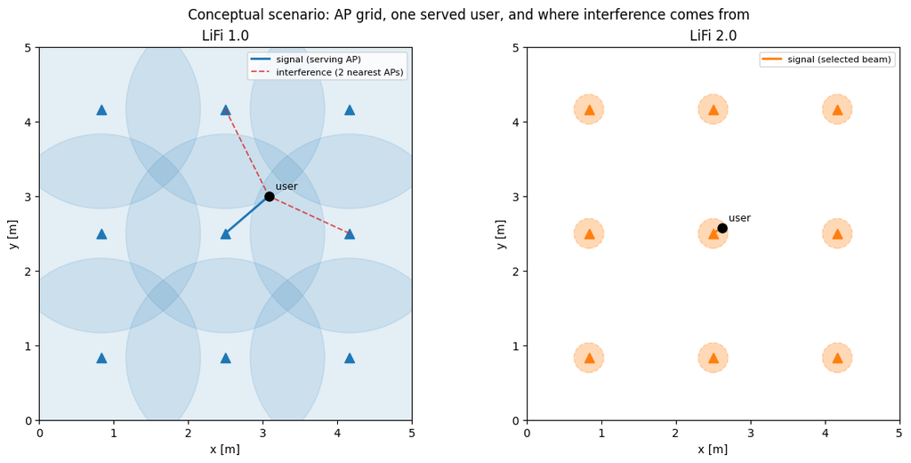

```python
fig, axes = plt.subplots(1, 2, figsize=(12, 5.6), constrained_layout=True)

n_side = 3
cell_pitch = ROOM / n_side
ap_positions = ap_lattice(n_side) # same helper used throughout, instead of rebuilding the lattice here
serving_idx = 4 # center AP of the 3x3 grid
serving_ap = ap_positions[serving_idx]

# LiFi 1.0: wide LED light that overlaps between access points
ax = axes[0]
for x, y in ap_positions:
    ax.add_patch(plt.Circle((x, y), cell_pitch * 0.8, color="tab:blue", alpha=0.12))
    ax.plot(x, y, "^", color="tab:blue", ms=9)
user = serving_ap + np.array([cell_pitch * 0.35, cell_pitch * 0.3])
ax.plot(*user, "o", color="black", ms=8, zorder=5)
ax.annotate("user", user, textcoords="offset points", xytext=(6, 6), fontsize=9)
ax.plot([serving_ap[0], user[0]], [serving_ap[1], user[1]], "-", color="tab:blue", lw=2, label="signal (serving AP)")

# only count interference from the 2 closest access points, the rest barely matter
others = np.array([p for i, p in enumerate(ap_positions) if i != serving_idx])
dist_to_user = np.hypot(others[:, 0] - user[0], others[:, 1] - user[1])
nearest2 = others[np.argsort(dist_to_user)[:2]]
for k, (x, y) in enumerate(nearest2):
    ax.plot([x, user[0]], [y, user[1]], "--", color="tab:red", lw=1.3, alpha=0.8,
            label="interference (2 nearest APs)" if k == 0 else None)
ax.set_xlim(0, ROOM); ax.set_ylim(0, ROOM); ax.set_aspect("equal")
ax.set_xlabel("x [m]"); ax.set_ylabel("y [m]")
ax.set_title("LiFi 1.0")
ax.legend(fontsize=8, loc="upper right")

# LiFi 2.0: narrow laser beams that don't overlap
ax = axes[1]
beam_reach = cell_pitch * 0.12 # illustrative: how far a single narrow beam actually reaches
for x, y in ap_positions:
    ax.add_patch(plt.Circle((x, y), beam_reach, color="tab:orange", alpha=0.3, ec="tab:orange", lw=1, ls="--"))
    ax.plot(x, y, "^", color="tab:orange", ms=9)
user2 = serving_ap + np.array([beam_reach * 0.6, beam_reach * 0.4])
ax.plot(*user2, "o", color="black", ms=8, zorder=5)
ax.annotate("user", user2, textcoords="offset points", xytext=(6, 6), fontsize=9)
ax.plot([serving_ap[0], user2[0]], [serving_ap[1], user2[1]], "-", color="tab:orange", lw=2, label="signal (selected beam)")
ax.set_xlim(0, ROOM); ax.set_ylim(0, ROOM); ax.set_aspect("equal")
ax.set_xlabel("x [m]"); ax.set_ylabel("y [m]")
ax.set_title("LiFi 2.0")
ax.legend(fontsize=8, loc="upper right")

fig.suptitle("Conceptual scenario: AP grid, one served user, and where interference comes from")
plt.show()
```

### 2.5 Directivity

Section 4.4 of the single-cell notebook already compared these two channel shapes at each technology's realistic power. Rather than redrawing those same maps, the radial cut below reuses that comparison but adds: the AP-to-AP spacing of the lattices used in the cases that follow. That spacing is what interference actually depends on, that is, how much signal each source still has left by the time it reaches a neighbouring cell.

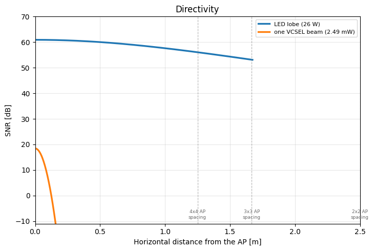

```python
# same power values as the single-cell notebook, now compared against the distance between access points
P2, _ = led_power(ap_lattice(2))

r = np.linspace(0, 2.5, 500)
d = np.sqrt(r**2 + dz**2); th = np.arctan2(r, dz)
h_led = np.where(th <= PSI_C, (M_LED + 1) * APD / (2 * np.pi * d**2) * np.cos(th)**M_LED * np.cos(th) * G_CONC, 0)
wz = W0 * np.sqrt(1 + (d / zR)**2)
h_v = np.where(th <= PSI_C, 2 / (np.pi * wz**2) * np.exp(-2 * r**2 / wz**2) * APD * G_CONC, 0)
with np.errstate(divide="ignore"):
    s_led = 10 * np.log10((RHO * P2 * h_led)**2 / (N0 * B_LED))
    s_v = 10 * np.log10((RHO * P_VCSEL * h_v)**2 / (N0 * B_VCSEL))

fig, ax = plt.subplots(figsize=(7.4, 5))
ax.plot(r, s_led, lw=2.4, color="tab:blue", label=f"LED lobe ({P2:.0f} W)")
ax.plot(r, s_v, lw=2.4, color="tab:orange", label=f"one VCSEL beam ({P_VCSEL * 1e3:.2f} mW)")

# distance between access points for each layout used below
for n in (2, 3, 4):
    spacing = ROOM / n
    ax.axvline(spacing, color="gray", lw=0.8, ls="--", alpha=0.6)
    ax.annotate(f"{n}x{n} AP\nspacing", (spacing, -9), fontsize=6.5, ha="center", color="dimgray")

ax.set_xlabel("Horizontal distance from the AP [m]")
ax.set_ylabel("SNR [dB]")
ax.set_ylim(-11, 70); ax.set_xlim(0, 2.5)
ax.set_title(f"Directivity")
ax.legend(fontsize=8, loc="upper right"); ax.grid(alpha=.3)
plt.tight_layout()
plt.show()
```

That is the entire interference story for Cases 1-4 in one picture: LiFi 1.0's wide lobe reaches its neighbours no matter how tightly the APs are packed, while LiFi 2.0's beam simply runs out before it gets there.

### 2.6 Metrics

$R(\mathbf{u})$ is the achievable-rate lower bound from Section 2.3, evaluated at each point $\mathbf{u}$ of the receiver grid which is the same rate expression used throughout the single-cell notebook. Every metric below is derived from it.

| Metric | Definition | Source |
| --- | --- | --- |
| Coverage | % of room points with $\gamma \ge$ 10 dB | complement of the outage metric in `[RIS-VLC]` eq. (13) |
| Mean rate | average of $R(\mathbf{u})$ over the room | `[Capacity-Bound]` |
| Cell-edge rate | 5th percentile of $R(\mathbf{u})$, the worst-served users | standard measure, not specific to either paper |
| Area spectral efficiency (ASE) | $N_{AP}\cdot\overline{R}/A_{room}$ [Mbit/s/m^2] | derived here, assuming one active user per AP |
| Energy efficiency | $P_{total}/(N_{AP}\cdot\overline{R})$ [nJ/bit] | inverse of the energy-efficiency metric in `[RIS-VLC]` eq. (14) |

The last two metrics keep the comparison fair: normalizing by area and by energy means a technology can't win just by using more APs or more watts.

### 2.7 Traceability of every decision

**Taken from the papers**

[output not shown]

**Own decisions/assumptions**

[output not shown]

## 3. Case 1: coverage across services

Every metric elsewhere in this notebook needs one SINR threshold to call a point "covered," but real services don't share one requirement: a basic control/messaging link needs far less SINR than an uncompressed video stream. Rather than assume a number, this case builds one from two steps: compare coverage across a range of plausible services, and only then fix a single threshold for every case that follows (the beam-count question is settled separately, in the single-cell notebook's own Section 6.2 and referenced in Section 2.1 here).

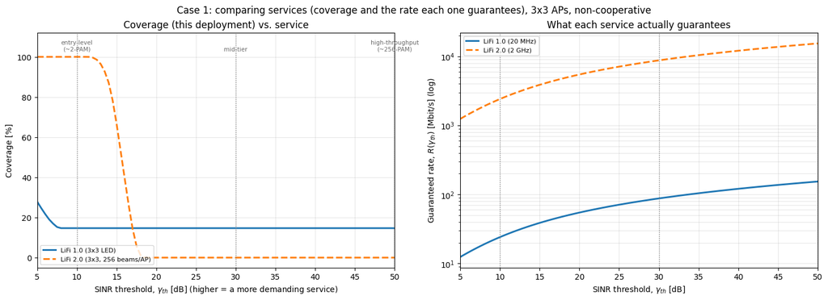

```
At 10 dB: LiFi 1.0 (3x3) coverage = 14.7%, LiFi 2.0 (3x3, 256 beams/AP) coverage = 100.0%

Guaranteed rate at 10 dB: LiFi 1.0 = 24.13 Mbit/s, LiFi 2.0 = 2413.1 Mbit/s
Guaranteed rate at 50 dB: LiFi 1.0 = 154.01 Mbit/s, LiFi 2.0 = 15400.9 Mbit/s
```

```python
# check coverage and data rate across a range of quality requirements (10-50 dB)
th_sweep_dB = np.linspace(5, 50, 91)
gamma_lin = 10**(th_sweep_dB / 10)

s_led_ref, _, _, _ = evaluate_led(3)
s_vcsel_ref, _, _ = evaluate_vcsel(3, M_BEAMS)
cov_led_th = [100 * np.mean(s_led_ref >= g) for g in gamma_lin]
cov_vcsel_th = [100 * np.mean(s_vcsel_ref >= g) for g in gamma_lin]

# minimum guaranteed data rate for each quality level
rate_led_th = 0.5 * B_LED * np.log2(1 + K_BOUND * gamma_lin) / 1e6 # [Mbit/s]
rate_vcsel_th = 0.5 * B_VCSEL * np.log2(1 + K_BOUND * gamma_lin) / 1e6 # [Mbit/s]

service_marks = [(10, "entry-level\n(~2-PAM)"), (30, "mid-tier"), (50, "high-throughput\n(~256-PAM)")]

fig, axes = plt.subplots(1, 2, figsize=(14.5, 5.2), constrained_layout=True)

ax = axes[0]
ax.plot(th_sweep_dB, cov_led_th, color="tab:blue", lw=2.2, label="LiFi 1.0 (3x3 LED)")
ax.plot(th_sweep_dB, cov_vcsel_th, color="tab:orange", lw=2.2, ls="--", label="LiFi 2.0 (3x3, 256 beams/AP)")
for th, lb in service_marks:
    ax.axvline(th, color="gray", ls=":", lw=1.0)
    ax.annotate(lb, (th, 103), ha="center", fontsize=7.5, color="dimgray")
ax.set_xlabel(r"SINR threshold, $\gamma_{th}$ [dB] (higher = a more demanding service)")
ax.set_ylabel("Coverage [%]")
ax.set_ylim(-5, 112); ax.set_xlim(5, 50)
ax.set_title("Coverage (this deployment) vs. service")
ax.legend(fontsize=8, loc="lower left")
ax.grid(alpha=.3)

ax = axes[1]
ax.plot(th_sweep_dB, rate_led_th, color="tab:blue", lw=2.2, label="LiFi 1.0 (20 MHz)")
ax.plot(th_sweep_dB, rate_vcsel_th, color="tab:orange", lw=2.2, ls="--", label="LiFi 2.0 (2 GHz)")
for th, lb in service_marks:
    ax.axvline(th, color="gray", ls=":", lw=1.0)
ax.set_yscale("log")
ax.set_xlabel(r"SINR threshold, $\gamma_{th}$ [dB]")
ax.set_ylabel("Guaranteed rate, $R(\gamma_{th})$ [Mbit/s] (log)")
ax.set_xlim(5, 50)
ax.set_title("What each service actually guarantees")
ax.legend(fontsize=8, loc="upper left")
ax.grid(alpha=.3, which="both")

fig.suptitle("Case 1: comparing services (coverage and the rate each one guarantees), 3x3 APs, non-cooperative")
plt.show()

th_10 = np.argmin(np.abs(th_sweep_dB - 10))
print(f"At 10 dB: LiFi 1.0 (3x3) coverage = {cov_led_th[th_10]:.1f}%, "
      f"LiFi 2.0 (3x3, 256 beams/AP) coverage = {cov_vcsel_th[th_10]:.1f}%")
print(f"\nGuaranteed rate at 10 dB: LiFi 1.0 = {rate_led_th[th_10]:.2f} Mbit/s, LiFi 2.0 = {rate_vcsel_th[th_10]:.1f} Mbit/s")
print(f"Guaranteed rate at 50 dB: LiFi 1.0 = {rate_led_th[-1]:.2f} Mbit/s, LiFi 2.0 = {rate_vcsel_th[-1]:.1f} Mbit/s")
```

At 10 dB, LiFi 1.0's 3x3 deployment covers 14.7% of the room, while LiFi 2.0 (3x3, 256 beams/AP) covers 100.0%. That gap does not hold at every threshold: LiFi 2.0's curve behaves almost like a step function across the swept range, since a single beam's own peak SINR (18.4 dB, Section 2.2) sits close to the middle of it. Below that point coverage is close to 100%; above it, close to 0%, with very little in between. LiFi 1.0's curve, by contrast, barely moves across the entire 10-50 dB span: its coverage is set by its FoV-limited area (Section 2.1), which has SINR headroom to spare well past any of these service levels.

This is the clearest illustration of why one fixed threshold is misleading: at the high end of the range (256-PAM, high-throughput services), LiFi 2.0's coverage collapses toward 0% while LiFi 1.0's holds; at the low end (2-PAM, entry-level services), the opposite is true. Neither number is "the" coverage of either technology: both depend on which service is being asked about.

The rate each service guarantees tells a third story, one that doesn't depend on deployment at all: at 10 dB, LiFi 1.0's 20 MHz link guarantees 24.1 Mbit/s while LiFi 2.0's 2 GHz link guarantees 2413.1 Mbit/s; at 50 dB, 154.0 vs 15400.9 Mbit/s. LiFi 2.0's guaranteed rate is exactly 100x LiFi 1.0's at every service level, since $R(\gamma)\propto B$ for a fixed $\gamma$: the bandwidth ratio, not the threshold, is what sets that gap, and it holds regardless of which service is being compared.

**Fixing the threshold.** The comparison above puts a specific number behind the choice: this notebook adopts $\gamma_{th}=10$ dB as its coverage threshold from here on, the low end of the service range just compared, and the point where LiFi 2.0's coverage is already close to its own maximum. 10 dB sits below a single VCSEL beam's own peak SINR (18.4 dB, Section 2.2), so coverage at this threshold reflects deployment and beam-grid choices, the way a coverage metric is supposed to: a real, computed number that depends on the scenario, not one fixed regardless of what the scenario can actually deliver.

With a threshold now fixed (and a beam count already adopted, Section 2.1), Case 2 turns to the direct comparison this sets up: the same infrastructure, given to each technology on its own terms.

## 4. Case 2: equal infrastructure

Case 1 used one representative deployment (3x3) for each technology, not matched between them in any principled way. This case removes that ambiguity: it fixes the same AP positions for both technologies, so any difference in the results comes only from the transmitter itself, not from a different deployment size. Equal infrastructure does not mean equal power, though, since each AP still runs at its own Section 2 operating point.

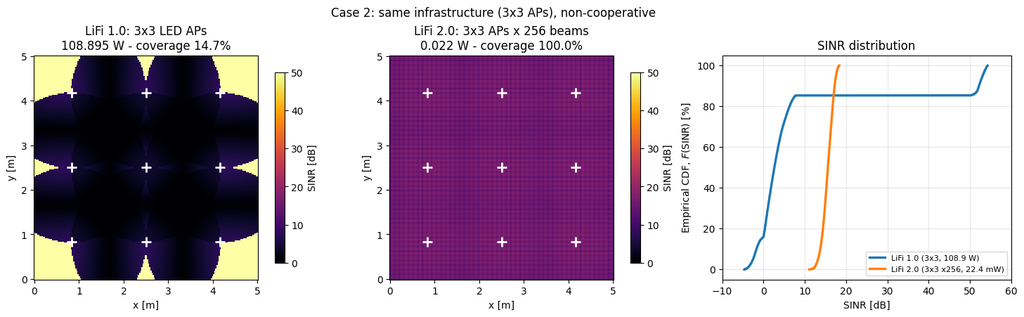

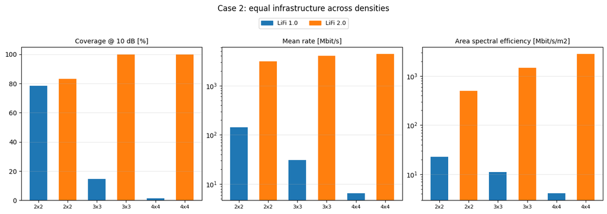

```python
iso = []
for n in [2, 3, 4]:
    s, P, nc, _ = evaluate_led(n)
    r, _ = metrics(s, B_LED, P, nc, f"{n}x{n} - LiFi 1.0 (LED)"); iso.append(r)
    s, P, nc = evaluate_vcsel(n, M_BEAMS)
    r, _ = metrics(s, B_VCSEL, P, nc, f"{n}x{n} - LiFi 2.0 (256 beams/AP)"); iso.append(r)
iso_df = pd.DataFrame(iso)

s_led, P_led, _, _ = evaluate_led(3)
s_v, P_v, _ = evaluate_vcsel(3, M_BEAMS)
cm = plt.cm.inferno.copy(); cm.set_bad("black")
fig = plt.figure(figsize=(15, 4.4), constrained_layout=True)
gs = fig.add_gridspec(1, 3)
for k, (S, ttl, P, cov) in enumerate([
        (s_led, "LiFi 1.0: 3x3 LED APs", P_led, 100*np.mean(s_led >= GAMMA_TH)),
        (s_v, "LiFi 2.0: 3x3 APs x 256 beams", P_v, 100*np.mean(s_v >= GAMMA_TH))]):
    ax = fig.add_subplot(gs[0, k])
    dB = np.where(S > 0, 10*np.log10(np.where(S > 0, S, 1)), np.nan)
    im = ax.pcolormesh(X, Y, dB, shading="auto", cmap=cm, vmin=0, vmax=50)
    ax.plot(ap_lattice(3)[:, 0], ap_lattice(3)[:, 1], "w+", ms=10, mew=2)
    ax.set_title(f"{ttl}\n{P:.3f} W - coverage {cov:.1f}%")
    ax.set_xlabel("x [m]"); ax.set_ylabel("y [m]"); ax.set_aspect("equal")
    fig.colorbar(im, ax=ax, label="SINR [dB]", shrink=0.85)

# cumulative distribution plot
ax = fig.add_subplot(gs[0, 2])
for S, lb, c in [(s_led, f"LiFi 1.0 (3x3, {P_led:.1f} W)", "tab:blue"),
                 (s_v, f"LiFi 2.0 (3x3 x256, {P_v*1e3:.1f} mW)", "tab:orange")]:
    d = np.sort(10*np.log10(np.maximum(S.ravel(), 1e-12)))
    ax.plot(d, np.linspace(0, 100, d.size), lw=2.4, color=c, label=lb)
ax.set_xlim(-10, 60); ax.set_xlabel("SINR [dB]"); ax.set_ylabel("Empirical CDF, $F(\mathrm{SINR})$ [%]")
ax.set_title(f"SINR distribution")
ax.legend(fontsize=8); ax.grid(alpha=.3)
fig.suptitle("Case 2: same infrastructure (3x3 APs), non-cooperative")
plt.show()

# bar chart comparing the 3 densities, same style as before
fig, axes = plt.subplots(1, 3, figsize=(13, 3.8), constrained_layout=True)
colors = iso_df["Deployment"].str.contains("1.0").map({True: "tab:blue", False: "tab:orange"})
x = np.arange(len(iso_df))
for ax, (col, ttl, logy) in zip(axes, [("Coverage [%]", f"Coverage @ {GAMMA_TH_DB:.0f} dB [%]", False),
                                        ("Mean rate [Mbit/s]", "Mean rate [Mbit/s]", True),
                                        ("ASE [Mbit/s/m2]", "Area spectral efficiency [Mbit/s/m2]", True)]):
    ax.bar(x, iso_df[col], color=colors, width=0.6)
    if logy:
        ax.set_yscale("log")
    ax.set_xticks(x); ax.set_xticklabels([d.split(" - ")[0] for d in iso_df.Deployment], fontsize=8)
    ax.set_title(ttl, fontsize=10); ax.grid(alpha=.3, axis="y")
fig.legend(handles=[Patch(color="tab:blue", label="LiFi 1.0"), Patch(color="tab:orange", label="LiFi 2.0")],
           loc="upper center", ncol=2, bbox_to_anchor=(0.5, 1.12), fontsize=9)
fig.suptitle("Case 2: equal infrastructure across densities", y=1.18)
plt.show()
```

At 3x3 APs, LiFi 2.0 delivers 4.05 Gbit/s mean rate at 22.4 mW total and 100.0% coverage @ 10 dB, against LiFi 1.0's 30.9 Mbit/s at 108.9 W and only 14.7% coverage. At this deployment size and threshold, LiFi 2.0 does not just win on rate, it wins on coverage too, and by a wide margin. The maps and CDF show why, and the two technologies still get there for very different underlying reasons.

The bar chart adds the density trend: LiFi 1.0's coverage and ASE both get worse as APs are added (interference grows faster than signal), while LiFi 2.0's coverage, mean rate and ASE all climb together, since more, smaller cells mean more beams close enough to reach that same 18.4 dB ceiling.

## 5. Case 3: cross-equivalence

Case 2 compared both technologies at the same deployment size and found very different outcomes. This case asks the question the other way around: instead of fixing the deployment and comparing outcomes, fix one technology's outcome as a target and ask what the other would need to match it (in both directions).

**Direction B's reference is LiFi 2.0's Case 2 deployment (3x3 APs, 256 beams/AP)**: a representative, already-analyzed configuration, used since LiFi 2.0 has no "cheapest 100%-coverage" deployment to anchor to instead. Does any LiFi 1.0 deployment match its mean rate and cell-edge rate?

Both charts below plot the actual rate values, in Mbit/s, not a normalized ratio: each configuration's own mean rate and cell-edge rate as bars, and the reference's own mean and cell-edge rate as two horizontal dashed lines (same color as the matching bar). Matching the reference just means the bar reaches its own line. The y-axis is log-scaled so that both large wins and large shortfalls stay readable on the same plot.

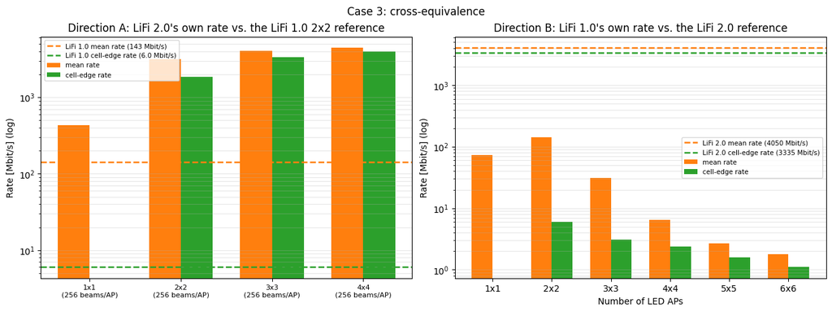

```
LiFi 1.0 2x2 reference: coverage=78.5%, mean rate=143.2 Mbit/s, cell-edge rate=6.0 Mbit/s, P=103.9 W

LiFi 2.0 configs (256 beams/AP) matching BOTH rate metrics of the LED 2x2 reference:
   cheapest: 2x2 APs (256 beams/AP)  ->  10.00 mW (10388x less optical power than the LED)
   coverage @ 10 dB there: 83.1%, which already beats the LED reference's own 78.5% (+4.6 points): not just a rate win, at this beam count and threshold.

Reverse direction: best LED mean rate = 143.2 Mbit/s vs 4050 Mbit/s required -> short by 28x, set by BANDWIDTH (20 MHz vs 2 GHz)
Cell-edge rate falls short by an even larger margin: best LED cell-edge rate = 6.0 Mbit/s vs 3335 Mbit/s required.
```

```python
# Case A: compare against a simple 2x2 LED layout
s_ref, P_ref, nc_ref, _ = evaluate_led(2)
ref, _ = metrics(s_ref, B_LED, P_ref, nc_ref, "REFERENCE")

rowsA = []
for n in [1, 2, 3, 4]:
    s, Pt, nc = evaluate_vcsel(n, M_BEAMS)
    r, _ = metrics(s, B_VCSEL, Pt, nc, f"{n}x{n} APs (256 beams/AP)")
    r["cov_vs_ref"] = r["Coverage [%]"] - ref["Coverage [%]"]
    both = r["Mean rate [Mbit/s]"] >= ref["Mean rate [Mbit/s]"] and r["Cell-edge rate [Mbit/s]"] >= max(ref["Cell-edge rate [Mbit/s]"], 1e-9)
    r["BOTH?"] = "*** YES ***" if both else ""
    rowsA.append(r)
dfA = pd.DataFrame(rowsA)

# Case B: compare against the bigger 3x3 laser layout from before
s_v, P_v, nc_v = evaluate_vcsel(3, M_BEAMS)
refv, _ = metrics(s_v, B_VCSEL, P_v, nc_v, "REF")
ns = [1, 2, 3, 4, 5, 6]
rowsB = []
for n in ns:
    s, Pt, nc, _ = evaluate_led(n)
    r, _ = metrics(s, B_LED, Pt, nc, f"{n}x{n} LED APs")
    rowsB.append(r)
dfB = pd.DataFrame(rowsB)

# solid bars = this setup's rate, dashed lines = the setup we're comparing it to
fig, ax = plt.subplots(1, 2, figsize=(13, 4.8), constrained_layout=True)
x = np.arange(len(dfA)); w = 0.35
ax[0].bar(x - w/2, dfA["Mean rate [Mbit/s]"], w, label="mean rate", color="tab:orange")
ax[0].bar(x + w/2, dfA["Cell-edge rate [Mbit/s]"], w, label="cell-edge rate", color="tab:green")
ax[0].axhline(ref["Mean rate [Mbit/s]"], color="tab:orange", ls="--", lw=1.8,
              label=f"LiFi 1.0 mean rate ({ref['Mean rate [Mbit/s]']:.0f} Mbit/s)")
ax[0].axhline(max(ref["Cell-edge rate [Mbit/s]"], 1e-9), color="tab:green", ls="--", lw=1.8,
              label=f"LiFi 1.0 cell-edge rate ({ref['Cell-edge rate [Mbit/s]']:.1f} Mbit/s)")
ax[0].set_yscale("log"); ax[0].set_xticks(x)
ax[0].set_xticklabels([f"{n}x{n}\n(256 beams/AP)" for n in [1, 2, 3, 4]], fontsize=8)
ax[0].set_ylabel("Rate [Mbit/s] (log)")
ax[0].set_title("Direction A: LiFi 2.0's own rate vs. the LiFi 1.0 2x2 reference")
ax[0].legend(fontsize=7.5); ax[0].grid(alpha=.3, axis="y", which="both")

wB = 0.35
ax[1].bar(np.arange(len(dfB)) - wB / 2, dfB["Mean rate [Mbit/s]"], wB, color="tab:orange", label="mean rate")
ax[1].bar(np.arange(len(dfB)) + wB / 2, dfB["Cell-edge rate [Mbit/s]"], wB, color="tab:green", label="cell-edge rate")
ax[1].axhline(refv["Mean rate [Mbit/s]"], color="tab:orange", ls="--", lw=1.8,
              label=f"LiFi 2.0 mean rate ({refv['Mean rate [Mbit/s]']:.0f} Mbit/s)")
ax[1].axhline(refv["Cell-edge rate [Mbit/s]"], color="tab:green", ls="--", lw=1.8,
              label=f"LiFi 2.0 cell-edge rate ({refv['Cell-edge rate [Mbit/s]']:.0f} Mbit/s)")
ax[1].set_yscale("log"); ax[1].set_xticks(np.arange(len(dfB)))
ax[1].set_xticklabels([f"{n}x{n}" for n in ns])
ax[1].set_xlabel("Number of LED APs"); ax[1].set_ylabel("Rate [Mbit/s] (log)")
ax[1].set_title("Direction B: LiFi 1.0's own rate vs. the LiFi 2.0 reference")
ax[1].legend(fontsize=7.5); ax[1].grid(alpha=.3, axis="y", which="both")
fig.suptitle("Case 3: cross-equivalence")
plt.show()

best = dfA[dfA["BOTH?"] != ""].sort_values("APs")
print(f"LiFi 1.0 2x2 reference: coverage={ref['Coverage [%]']:.1f}%, mean rate={ref['Mean rate [Mbit/s]']:.1f} Mbit/s, "
      f"cell-edge rate={ref['Cell-edge rate [Mbit/s]']:.1f} Mbit/s, P={P_ref:.1f} W")
print("\nLiFi 2.0 configs (256 beams/AP) matching BOTH rate metrics of the LED 2x2 reference:")
if best.empty:
    print("  none in this sweep")
else:
    b = best.iloc[0]
    print(f"   cheapest: {b['Deployment']}  ->  {b['P total [W]']*1000:.2f} mW "
          f"({P_ref/b['P total [W]']:.0f}x less optical power than the LED)")
    print(f"   coverage @ {GAMMA_TH_DB:.0f} dB there: {b['Coverage [%]']:.1f}%, "
          f"which already {'beats' if b['cov_vs_ref']>=0 else 'falls short of'} "
          f"the LED reference's own {ref['Coverage [%]']:.1f}% ({b['cov_vs_ref']:+.1f} points): "
          "not just a rate win, at this beam count and threshold.")
print(f"\nReverse direction: best LED mean rate = {dfB['Mean rate [Mbit/s]'].max():.1f} Mbit/s vs "
      f"{refv['Mean rate [Mbit/s]']:.0f} Mbit/s required -> short by "
      f"{refv['Mean rate [Mbit/s]']/dfB['Mean rate [Mbit/s]'].max():.0f}x, set by BANDWIDTH (20 MHz vs 2 GHz)")
print(f"Cell-edge rate falls short by an even larger margin: best LED cell-edge rate = "
      f"{dfB['Cell-edge rate [Mbit/s]'].max():.1f} Mbit/s vs {refv['Cell-edge rate [Mbit/s]']:.0f} Mbit/s required.")
```

**Direction A.** Rate and cell-edge rate are both matched at trivial cost: 2x2 APs at the standard 256 beams/AP (1024 beams total) already beat the LED reference on both, at 10.0 mW against the LED's 103.9 W. At this notebook's 10 dB threshold, that same configuration's coverage (83.1%) also already exceeds the LED reference's own 78.5%: the cheapest rate-matching configuration happens to match coverage too, not just the two rate metrics it was chosen for.

**Direction B.** No LED deployment comes close to LiFi 2.0's mean rate or cell-edge rate: since $R \propto B$, the 20 MHz vs 2 GHz gap is a bandwidth ceiling no number of LEDs or added watts can close.

## 6. Case 4: scalability and densification

This case asks whether adding infrastructure actually adds capacity, which is the question that could decide whether either technology is viable for a 6G-style ultra-dense deployment.

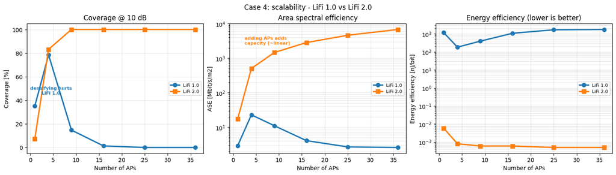

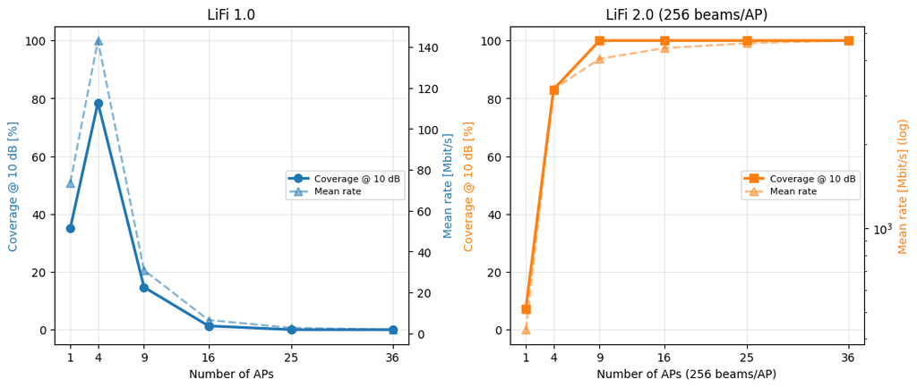

|  | Deployment | APs | P total [W] | Coverage [%] | Mean rate [Mbit/s] | ASE [Mbit/s/m2] | Energy efficiency [nJ/bit] |
| --- | --- | --- | --- | --- | --- | --- | --- |
| 0 | LiFi 1.0 (1x1) | 1 | 84.8819 | 35.1 | 73.7 | 2.9 | 1151.3957 |
| 1 | LiFi 1.0 (2x2) | 4 | 103.8835 | 78.5 | 143.2 | 22.9 | 181.3559 |
| 2 | LiFi 1.0 (3x3) | 9 | 108.8946 | 14.7 | 30.9 | 11.1 | 391.2410 |
| 3 | LiFi 1.0 (4x4) | 16 | 110.5736 | 1.3 | 6.5 | 4.1 | 1068.2005 |
| 4 | LiFi 1.0 (5x5) | 25 | 111.3198 | 0.0 | 2.7 | 2.7 | 1662.1118 |
| 5 | LiFi 1.0 (6x6) | 36 | 111.7174 | 0.0 | 1.8 | 2.6 | 1737.1498 |
| 6 | LiFi 2.0 (1x1, 256 beams/AP) | 1 | 0.0025 | 7.2 | 431.7 | 17.3 | 0.0058 |
| 7 | LiFi 2.0 (2x2, 256 beams/AP) | 4 | 0.0100 | 83.1 | 3148.9 | 503.8 | 0.0008 |
| 8 | LiFi 2.0 (3x3, 256 beams/AP) | 9 | 0.0224 | 100.0 | 4050.0 | 1458.0 | 0.0006 |
| 9 | LiFi 2.0 (4x4, 256 beams/AP) | 16 | 0.0399 | 100.0 | 4423.4 | 2831.0 | 0.0006 |
| 10 | LiFi 2.0 (5x5, 256 beams/AP) | 25 | 0.0623 | 100.0 | 4608.7 | 4608.7 | 0.0005 |
| 11 | LiFi 2.0 (6x6, 256 beams/AP) | 36 | 0.0897 | 100.0 | 4711.8 | 6785.0 | 0.0005 |

```python
dens = []
for n in [1, 2, 3, 4, 5, 6]:
    s, Pt, nc, Ev = evaluate_led(n)
    r, _ = metrics(s, B_LED, Pt, nc, f"LiFi 1.0 ({n}x{n})")
    r["Lighting"] = "OK" if Ev.max() <= E_MAX else f"peak {Ev.max():.0f} lux > 800"
    dens.append(r)
for n in [1, 2, 3, 4, 5, 6]:
    s, Pt, nc = evaluate_vcsel(n, M_BEAMS)
    r, _ = metrics(s, B_VCSEL, Pt, nc, f"LiFi 2.0 ({n}x{n}, 256 beams/AP)"); dens.append(r)
ddf = pd.DataFrame(dens)
L = ddf[ddf.Deployment.str.contains("1.0")]; V = ddf[ddf.Deployment.str.contains("2.0")]

fig, ax = plt.subplots(1, 3, figsize=(15, 4.2), constrained_layout=True)
for a, key, ttl, logy in [(ax[0], "Coverage [%]", f"Coverage @ {GAMMA_TH_DB:.0f} dB", False),
                          (ax[1], "ASE [Mbit/s/m2]", "Area spectral efficiency", True),
                          (ax[2], "Energy efficiency [nJ/bit]", "Energy efficiency (lower is better)", True)]:
    plot = a.semilogy if logy else a.plot
    plot(L.APs, L[key], "o-", color="tab:blue", lw=2.4, ms=7, label="LiFi 1.0")
    plot(V.APs, V[key], "s-", color="tab:orange", lw=2.4, ms=7, label="LiFi 2.0")
    a.set_xlabel("Number of APs"); a.set_ylabel(key); a.set_title(ttl)
    a.legend(fontsize=8); a.grid(alpha=.3, which="both")
ax[0].set_ylim(-5, 105)
ax[0].annotate("densifying hurts\nLiFi 1.0", (4.5, 45), fontsize=8, color="tab:blue",
               ha="center", weight="bold")
ax[1].annotate("adding APs adds\ncapacity (~linear)", (2.5, 2500), fontsize=8,
               color="tab:orange", weight="bold")
fig.suptitle("Case 4: scalability - LiFi 1.0 vs LiFi 2.0")
plt.show()

# coverage and data rate as we add more access points
fig, axes = plt.subplots(1, 2, figsize=(11, 4.6), constrained_layout=True)

ax = axes[0]; ax2 = ax.twinx()
l1, = ax.plot(L.APs, L["Coverage [%]"], "o-", color="tab:blue", lw=2.4, ms=7,
              label=f"Coverage @ {GAMMA_TH_DB:.0f} dB")
l2, = ax2.plot(L.APs, L["Mean rate [Mbit/s]"], "^--", color="tab:blue", lw=1.8, ms=7,
               alpha=0.55, label="Mean rate")
ax.set_xlabel("Number of APs"); ax.set_xticks(L.APs)
ax.set_ylabel(f"Coverage @ {GAMMA_TH_DB:.0f} dB [%]", color="tab:blue"); ax.set_ylim(-5, 105)
ax2.set_ylabel("Mean rate [Mbit/s]", color="tab:blue")
ax.set_title("LiFi 1.0")
ax.legend(handles=[l1, l2], fontsize=8, loc="center right")
ax.grid(alpha=.3)

ax = axes[1]; ax2 = ax.twinx()
l1, = ax.plot(V.APs, V["Coverage [%]"], "s-", color="tab:orange", lw=2.4, ms=7,
              label=f"Coverage @ {GAMMA_TH_DB:.0f} dB")
l2, = ax2.plot(V.APs, V["Mean rate [Mbit/s]"], "^--", color="tab:orange", lw=1.8, ms=7,
               alpha=0.55, label="Mean rate")
ax2.set_yscale("log")
ax.set_xlabel("Number of APs (256 beams/AP)"); ax.set_xticks(V.APs)
ax.set_ylabel(f"Coverage @ {GAMMA_TH_DB:.0f} dB [%]", color="tab:orange"); ax.set_ylim(-5, 105)
ax2.set_ylabel("Mean rate [Mbit/s] (log)", color="tab:orange")
ax.set_title("LiFi 2.0 (256 beams/AP)")
ax.legend(handles=[l1, l2], fontsize=8, loc="center right")
ax.grid(alpha=.3)


plt.show()

ddf[["Deployment", "APs", "P total [W]", "Coverage [%]", "Mean rate [Mbit/s]",
     "ASE [Mbit/s/m2]", "Energy efficiency [nJ/bit]"]]
```

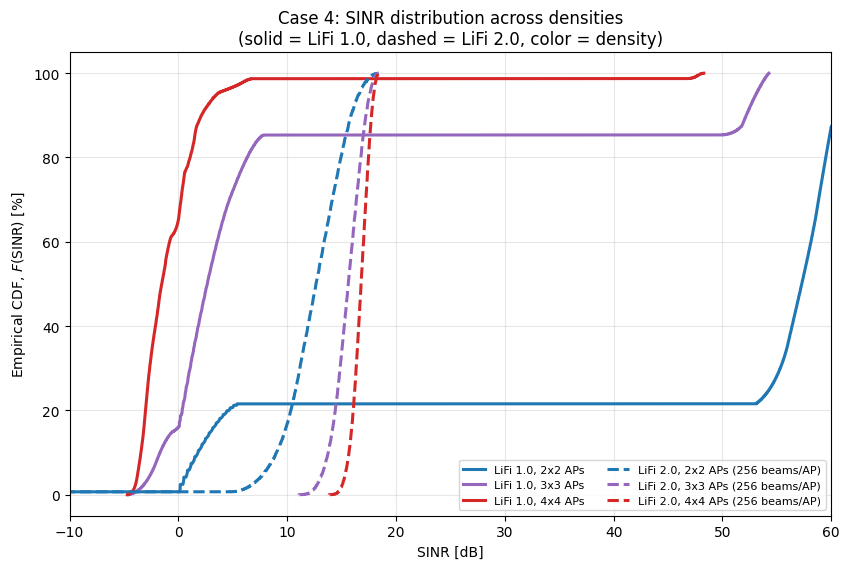

```python
# same idea as before, but now for every density: solid lines are LiFi 1.0, dashed are LiFi 2.0
fig, ax = plt.subplots(figsize=(8.6, 5.8))
density_colors = {2: "tab:blue", 3: "tab:purple", 4: "tab:red"}

for n, c in density_colors.items():
    s, _, _, _ = evaluate_led(n)
    d = np.sort(10 * np.log10(np.maximum(s.ravel(), 1e-12)))
    ax.plot(d, np.linspace(0, 100, d.size), lw=2.2, color=c, ls="-", label=f"LiFi 1.0, {n}x{n} APs")

for n, c in density_colors.items():
    s, _, _ = evaluate_vcsel(n, M_BEAMS)
    d = np.sort(10 * np.log10(np.maximum(s.ravel(), 1e-12)))
    ax.plot(d, np.linspace(0, 100, d.size), lw=2.2, color=c, ls="--", label=f"LiFi 2.0, {n}x{n} APs (256 beams/AP)")

ax.set_xlim(-10, 60)
ax.set_xlabel("SINR [dB]")
ax.set_ylabel(r"Empirical CDF, $F(\mathrm{SINR})$ [%]")
ax.set_title("Case 4: SINR distribution across densities\n(solid = LiFi 1.0, dashed = LiFi 2.0, color = density)")
ax.legend(fontsize=8, ncol=2)
ax.grid(alpha=.3)
plt.tight_layout()
plt.show()
```

The two technologies now scale in opposite directions on coverage too, not just on throughput: the CDF above makes this a distribution-wide effect, not just a change in one summary number. LiFi 1.0's whole curve shifts left as density grows; LiFi 2.0's shifts right and, past 3x3, sits almost entirely above 10 dB.

- **LiFi 1.0 doesn't scale without coordination.** From 2x2 onward, coverage collapses as density increases (78.5% -> 14.7% -> 1.3% -> 0.0% -> 0.0%), since every new LED is just a new interferer inside everybody's FoV, and energy per bit gets worse, not better.

(The 1x1 point looks better on coverage, but a single AP also overshoots the 800 lux peak ceiling there, so it is not a fair alternative, just a reminder that a lone AP is not how this technology is meant to be deployed.) Area spectral efficiency peaks at 2x2 (22.9 Mbit/s/m²) and then drops to 2.6 by 6x6. Without coordination, LiFi 1.0 becomes interference-limited at very low density, and adding more APs only makes it worse on every metric here.

- **LiFi 2.0 scales on both throughput and coverage.** Coverage climbs from 7.2% at 1x1 to 83.1% at 2x2 and saturates at 100.0% from 3x3 onward (at this notebook's 10 dB threshold, Section 3), while area spectral efficiency keeps increasing with density throughout, from 17.3 Mbit/s/m² at 1x1 to 6785.0 at 6x6, because narrow beams keep cells isolated: an added AP adds capacity instead of stealing it from its neighbours, and, once enough beams cover the room, adds coverage too.

A 6G indoor network needs to add capacity by densifying. LiFi 1.0 can only do that if interference is actively managed; LiFi 2.0 scales cleanly on its own, on both metrics, once it is dense enough to saturate coverage.

## 7. Cooperative networks

LiFi 1.0 collapses under densification because of co-channel interference. The classical fix is to make neighbouring APs cooperate: transmit the same signal to the same user, so the interference gets converted into useful signal instead of just suppressed. Both reference papers point this way: `[RIS-VLC]` (Sec. I) cites cooperative techniques for attocell networks, and `[VCSEL-Precoding]` builds its whole system around a cooperative broadcast model (Sec. II-B).

With perfect synchronization, the optical amplitudes add before the square-law detection, so the useful signal becomes the square of the sum rather than a sum of squares (same structure as `[VCSEL-Precoding]` eqs. (9)-(11)):

$$\gamma_{\text{coop}} = \frac{\left(\sum_{i \in \mathcal{C}} \rho P_i H_i\right)^{2}}{N_0 B + \sum_{i \notin \mathcal{C}} \left(\rho P_i H_i\right)^{2}}$$

This section asks what cooperation is still worth once thresholds and beam counts are chosen realistically (Section 3): LiFi 1.0 needs it to survive densification at all. Does LiFi 2.0 still need it, now that a single beam's own peak SINR (18.4 dB, Section 2.2) already sits above this notebook's 10 dB threshold?

Two figures answer two questions here.

- The first shows how coverage vs. density changes under each cooperation regime, one panel per technology.
- The second shows what cooperation does mechanically for LiFi 1.0: the same LED deployment (3x3), same SINR map, just with the interference term handled differently across the three regimes.

These results assume perfect synchronization, perfect channel state information and no backhaul cost, so read the cooperation gains as an upper bound, not something immediately achievable.

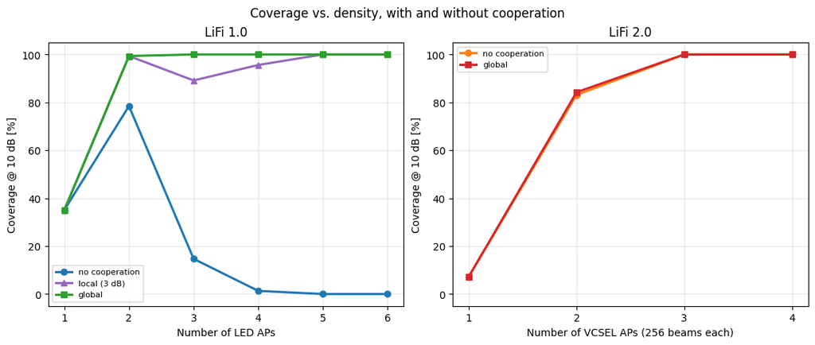

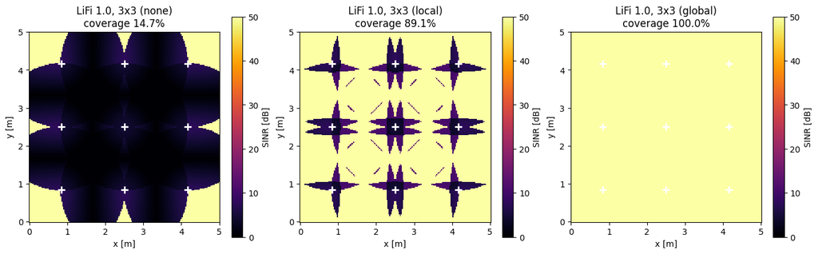

```
Coverage from GLOBAL cooperation (none -> global):
  LiFi 1.0 1x1:  35.1% ->  35.1%  (  +0.0 points)
  LiFi 1.0 2x2:  78.5% ->  99.3%  ( +20.9 points)
  LiFi 1.0 3x3:  14.7% -> 100.0%  ( +85.3 points)
  LiFi 1.0 4x4:   1.3% -> 100.0%  ( +98.7 points)
  LiFi 1.0 5x5:   0.0% -> 100.0%  (+100.0 points)
  LiFi 1.0 6x6:   0.0% -> 100.0%  (+100.0 points)
  LiFi 2.0 1x1:  7.25% ->  7.25%  ( +0.00 points)
  LiFi 2.0 2x2: 83.11% -> 84.23%  ( +1.12 points)
  LiFi 2.0 3x3: 100.00% -> 100.00%  ( +0.00 points)
  LiFi 2.0 4x4: 100.00% -> 100.00%  ( +0.00 points)
```

```python
ns_l, ns_v = [1, 2, 3, 4, 5, 6], [1, 2, 3, 4]
cl = {cp: [100*np.mean(evaluate_led(n, coop=cp)[0] >= GAMMA_TH) for n in ns_l]
      for cp in ["none", "local", "global"]}
cv = {cp: [100*np.mean(evaluate_vcsel(n, M_BEAMS, coop=cp)[0] >= GAMMA_TH) for n in ns_v]
      for cp in ["none", "global"]}

fig, axes = plt.subplots(1, 2, figsize=(11, 4.6), constrained_layout=True)

a = axes[0]
for cp, st, lb, c in [("none", "o-", "no cooperation", "tab:blue"),
                      ("local", "^-", "local (3 dB)", "tab:purple"),
                      ("global", "s-", "global", "tab:green")]:
    a.plot(ns_l, cl[cp], st, lw=2.2, ms=6, color=c, label=lb)
a.set_xlabel("Number of LED APs"); a.set_ylabel(f"Coverage @ {GAMMA_TH_DB:.0f} dB [%]")
a.set_xticks(ns_l); a.set_ylim(-5, 105); a.legend(fontsize=8); a.grid(alpha=.3)
a.set_title("LiFi 1.0")

a = axes[1]
for cp, st, lb, c in [("none", "o-", "no cooperation", "tab:orange"),
                      ("global", "s-", "global", "tab:red")]:
    a.plot(ns_v, cv[cp], st, lw=2.2, ms=6, color=c, label=lb)
a.set_xlabel("Number of VCSEL APs (256 beams each)"); a.set_ylabel(f"Coverage @ {GAMMA_TH_DB:.0f} dB [%]")
a.set_xticks(ns_v); a.set_ylim(-5, 105); a.legend(fontsize=8); a.grid(alpha=.3)
a.set_title("LiFi 2.0")

fig.suptitle("Coverage vs. density, with and without cooperation")
plt.show()

# maps showing how the signal improves once access points cooperate
cm = plt.cm.inferno.copy(); cm.set_bad("black")
fig, axes = plt.subplots(1, 3, figsize=(13.5, 4.4), constrained_layout=True)
for a, cp in zip(axes, ["none", "local", "global"]):
    s, P, nc, _ = evaluate_led(3, coop=cp)
    dB = np.where(s > 0, 10*np.log10(np.where(s > 0, s, 1)), np.nan)
    im = a.pcolormesh(X, Y, dB, shading="auto", cmap=cm, vmin=0, vmax=50)
    a.plot(ap_lattice(3)[:, 0], ap_lattice(3)[:, 1], "w+", ms=9, mew=2)
    a.set_title(f"LiFi 1.0, 3x3 ({cp})\ncoverage {100*np.mean(s >= GAMMA_TH):.1f}%")
    a.set_xlabel("x [m]"); a.set_ylabel("y [m]"); a.set_aspect("equal")
    fig.colorbar(im, ax=a, label="SINR [dB]", shrink=0.85)
plt.show()

print("Coverage from GLOBAL cooperation (none -> global):")
for n, a_, b_ in zip(ns_l, cl["none"], cl["global"]):
    print(f"  LiFi 1.0 {n}x{n}: {a_:5.1f}% -> {b_:5.1f}%  ({b_-a_:+6.1f} points)")
for n, a_, b_ in zip(ns_v, cv["none"], cv["global"]):
    print(f"  LiFi 2.0 {n}x{n}: {a_:5.2f}% -> {b_:5.2f}%  ({b_-a_:+6.2f} points)")
```

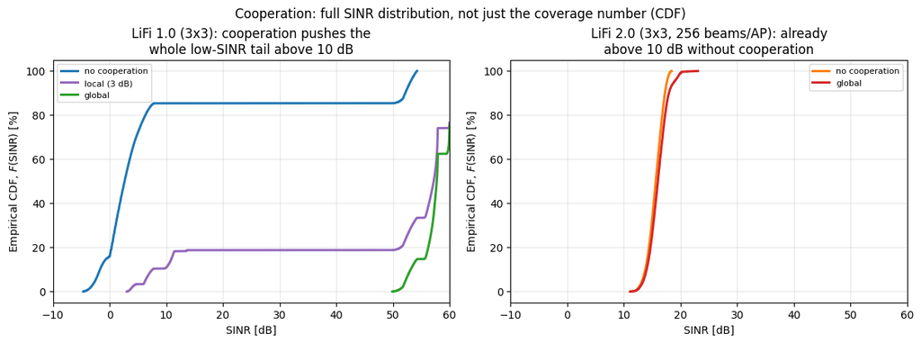

```python
# same layout, showing how much cooperation helps overall
fig, ax = plt.subplots(1, 2, figsize=(12, 4.4), constrained_layout=True)

for cp, c, lb in [("none", "tab:blue", "no cooperation"), ("local", "tab:purple", "local (3 dB)"),
                  ("global", "tab:green", "global")]:
    s, _, _, _ = evaluate_led(3, coop=cp)
    d = np.sort(10 * np.log10(np.maximum(s.ravel(), 1e-12)))
    ax[0].plot(d, np.linspace(0, 100, d.size), lw=2.2, color=c, label=lb)
ax[0].set_xlim(-10, 60); ax[0].set_xlabel("SINR [dB]"); ax[0].set_ylabel(r"Empirical CDF, $F(\mathrm{SINR})$ [%]")
ax[0].set_title(f"LiFi 1.0 (3x3): cooperation pushes the\nwhole low-SINR tail above {GAMMA_TH_DB:.0f} dB")
ax[0].legend(fontsize=8); ax[0].grid(alpha=.3)

for cp, c, lb in [("none", "tab:orange", "no cooperation"), ("global", "tab:red", "global")]:
    s, _, _ = evaluate_vcsel(3, M_BEAMS, coop=cp)
    d = np.sort(10 * np.log10(np.maximum(s.ravel(), 1e-12)))
    ax[1].plot(d, np.linspace(0, 100, d.size), lw=2.2, color=c, label=lb)
ax[1].set_xlim(-10, 60); ax[1].set_xlabel("SINR [dB]"); ax[1].set_ylabel(r"Empirical CDF, $F(\mathrm{SINR})$ [%]")
ax[1].set_title(f"LiFi 2.0 (3x3, 256 beams/AP): already\nabove {GAMMA_TH_DB:.0f} dB without cooperation")
ax[1].legend(fontsize=8); ax[1].grid(alpha=.3)

fig.suptitle("Cooperation: full SINR distribution, not just the coverage number (CDF)")
plt.show()
```

## 8. Results and discussion

### 8.1 Everything on one map

Cases 1-4 and Section 7 each looked at one question in isolation. The figure below collects representative deployments from all of them onto one page: four panels, one per metric, every deployment as a bar, so the two technologies can be read off side by side.

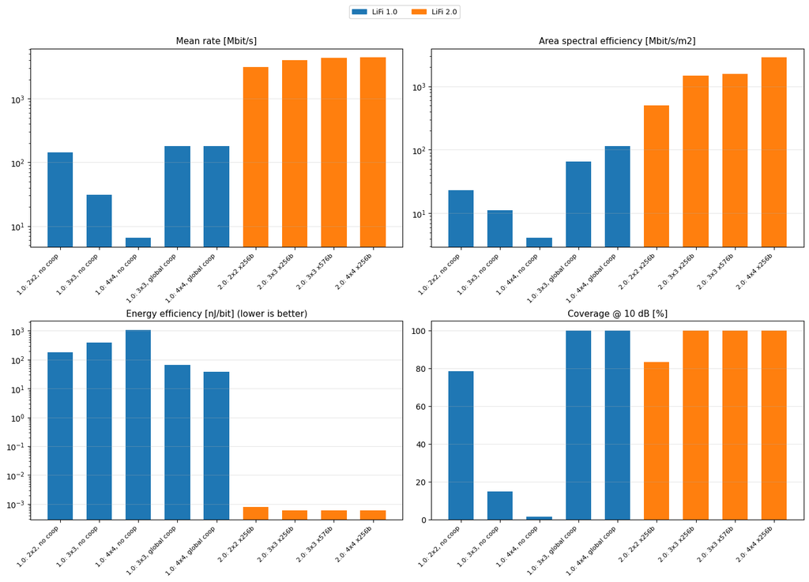

|  | Deployment | APs | P total [W] | Coverage [%] | Mean rate [Mbit/s] | Cell-edge rate [Mbit/s] | ASE [Mbit/s/m2] | Energy efficiency [nJ/bit] |
| --- | --- | --- | --- | --- | --- | --- | --- | --- |
| 0 | 1.0: 2x2, no coop | 4 | 103.8835 | 78.5 | 143.2 | 6.0 | 22.9 | 181.3559 |
| 1 | 1.0: 3x3, no coop | 9 | 108.8946 | 14.7 | 30.9 | 3.1 | 11.1 | 391.2410 |
| 2 | 1.0: 4x4, no coop | 16 | 110.5736 | 1.3 | 6.5 | 2.4 | 4.1 | 1068.2005 |
| 3 | 1.0: 3x3, global coop | 9 | 108.8946 | 100.0 | 180.0 | 161.5 | 64.8 | 67.2011 |
| 4 | 1.0: 4x4, global coop | 16 | 110.5736 | 100.0 | 180.0 | 163.0 | 115.2 | 38.3968 |
| 5 | 2.0: 2x2 x256b | 4 | 0.0100 | 83.1 | 3148.9 | 1855.3 | 503.8 | 0.0008 |
| 6 | 2.0: 3x3 x256b | 9 | 0.0224 | 100.0 | 4050.0 | 3335.2 | 1458.0 | 0.0006 |
| 7 | 2.0: 3x3 x576b | 9 | 0.0224 | 100.0 | 4387.2 | 3980.1 | 1579.4 | 0.0006 |
| 8 | 2.0: 4x4 x256b | 16 | 0.0399 | 100.0 | 4423.4 | 3983.8 | 2831.0 | 0.0006 |

```python
summary = []
for lbl, n, cp in [("1.0: 2x2, no coop", 2, "none"), ("1.0: 3x3, no coop", 3, "none"),
                   ("1.0: 4x4, no coop", 4, "none"), ("1.0: 3x3, global coop", 3, "global"),
                   ("1.0: 4x4, global coop", 4, "global")]:
    s, P, nc, _ = evaluate_led(n, coop=cp)
    r, _ = metrics(s, B_LED, P, nc, lbl, tech="LiFi 1.0"); summary.append(r)
for lbl, n, m in [("2.0: 2x2 x256b", 2, M_BEAMS), ("2.0: 3x3 x256b", 3, M_BEAMS),
                  ("2.0: 3x3 x576b", 3, 24), ("2.0: 4x4 x256b", 4, M_BEAMS)]:
    s, P, nc = evaluate_vcsel(n, m)
    r, _ = metrics(s, B_VCSEL, P, nc, lbl, tech="LiFi 2.0", **{"Total beams": nc*m*m})
    summary.append(r)
sdf = pd.DataFrame(summary)

# one bar chart per metric, easier to read than cramming it all into one plot
fig, axes = plt.subplots(2, 2, figsize=(14, 9.5), constrained_layout=True)
colors = sdf["tech"].map({"LiFi 1.0": "tab:blue", "LiFi 2.0": "tab:orange"})
x = np.arange(len(sdf))

# rate first since it's the main metric here, coverage last
panels = [
    ("Mean rate [Mbit/s]", "Mean rate [Mbit/s]", True),
    ("ASE [Mbit/s/m2]", "Area spectral efficiency [Mbit/s/m2]", True),
    ("Energy efficiency [nJ/bit]", "Energy efficiency [nJ/bit] (lower is better)", True),
    ("Coverage [%]", f"Coverage @ {GAMMA_TH_DB:.0f} dB [%]", False),
]
for ax, (col, title, log_scale) in zip(axes.ravel(), panels):
    ax.bar(x, sdf[col], color=colors, width=0.65)
    if log_scale:
        ax.set_yscale("log")
    ax.set_xticks(x); ax.set_xticklabels(sdf["Deployment"], rotation=45, ha="right", fontsize=8)
    ax.set_title(title, fontsize=11)
    ax.grid(alpha=.3, axis="y")

fig.legend(handles=[Patch(color="tab:blue", label="LiFi 1.0"), Patch(color="tab:orange", label="LiFi 2.0")],
           loc="upper center", ncol=2, bbox_to_anchor=(0.5, 1.06), fontsize=9)

plt.show()

sdf[["Deployment", "APs", "P total [W]", "Coverage [%]", "Mean rate [Mbit/s]",
     "Cell-edge rate [Mbit/s]", "ASE [Mbit/s/m2]", "Energy efficiency [nJ/bit]"]]
```

### 8.2 Discussion

**Power alone is not a fair comparison.** Per watt, the two technologies look four orders of magnitude apart, but the LED's watts are not spent on communication: they light the room, and communication rides for free on top of that budget. For LiFi 2.0, transmit power is the only cost there is.

**Directivity explains most of the rest.** It is what makes the LED a good lamp and a poor multi-cell transmitter (its wide lobe sprays energy into every neighbouring cell), and what keeps the VCSEL's cells isolated by geometry alone. Concentrating a fixed eye-safe power into a narrow beam also gives that beam's own peak SNR (18.4 dB) enough headroom to clear this notebook's 10 dB threshold on its own (Section 2.2), a deliberately chosen, service-grounded bar (Section 3). So directivity buys isolation, throughput, and, at this threshold, coverage too.

**Putting the cases together, LiFi 2.0 has four real advantages, and the single-cell notebook could only see one of them:**

- Bandwidth (2 GHz vs 20 MHz) opens a ~28x rate gap no LED deployment can close (Section 5).
- Directivity gives interference-free densification for throughput and ASE.
- Its power is not tied to any lighting requirement.
- Once enough beams cover a cell (Section 3), it reaches full coverage without needing cooperation at all, unlike LiFi 1.0, which needs cooperation (Section 7) just to survive densification.

## 9. Conclusions

| Feature | LiFi 1.0 (LED) | LiFi 2.0 (VCSEL) |
| --- | --- | --- |
| Optical source | LED | VCSEL array with beam selection |
| Emission pattern | Lambertian | Gaussian beam |
| Available power | High (tens of W, set by lighting) | Limited by eye safety (2.49 mW per emitter) |
| Directivity | Low | High |
| Coverage @ 10 dB (representative 3x3) | Low (14.7%, interference-limited at this density) | Full (100.0%, saturates from 3x3 onward, Section 3) |
| Interference | High (wide lobes overlap between cells) | Low (beams stay within their own cell) |
| Throughput | Moderate (capped by 20 MHz bandwidth) | Very high (multi-Gbit/s, 2 GHz bandwidth) |
| What fixes its main gap | Cooperation (100% coverage at 3x3+) | Densifying past ~2x2 (256 beams/AP); cooperation adds little once coverage saturates (Section 7) |
| Main limitation | Co-channel interference | Per-beam SINR ceiling (18.4 dB) still caps how demanding a service it can meet without cooperation (Section 3) |

So the real question is not "does LiFi 2.0 always win" but "at what density": below about 3x3 APs its coverage still needs either more beams or cooperation; at or above it, LiFi 2.0 already dominates on both coverage and capacity.

**Cooperation:**

**For 6G, this points to two different roles, not one clear winner.** LiFi 1.0 fits as a low-cost overlay on existing lighting infrastructure, provided its APs are coordinated; without that, densifying only makes it worse. LiFi 2.0 scales into an ultra-dense, multi-gigabit network on throughput and, once dense enough, on coverage too, without needing cooperation or the full precoding this notebook deliberately simplified away (Section 10), though both remain available for a stricter service level than the one adopted here (Section 3). The two are complementary, not competing: what makes LiFi 1.0 look weak (power dictated by lighting) is what makes it free, and what makes LiFi 2.0's coverage a genuine, competitive number, rather than an architectural 0%, is simply asking the right question about which service it needs to serve, before asking whether it can.

## 10. Limitations

The cases above compare LiFi 1.0 and LiFi 2.0 under a specific set of modelling choices. The main ones, and how they could shift the results, are listed here.

**1.** This notebook uses the realistic $w_0 = 5\ \mu m$ from `[Eye-Safety]`, not the sub-wavelength 0.45 um listed in `[VCSEL-Precoding]` Table I, and ports the resulting 2.49 mW eye-safe ceiling directly from the single-cell notebook's own calculation rather than re-deriving a nearby number. That choice sets the beam width (12 cm vs 1.34 m), the eye-safe power (2.49 mW vs an inflated 225 mW), and, as a direct consequence, the central finding that a single beam's peak SNR sits at 18.4 dB (Section 2.2), comfortably above this notebook's own 10 dB coverage threshold (Section 3): consistent with the single-cell notebook's own 18.3 dB finding against that same 10 dB bar there (the small difference from this notebook's 18.4 dB is grid discretization, not a modelling change). All three (beam width, eye-safe power, peak SNR) have to stay consistent with each other and with the single-cell notebook.

**2. Simplified beamforming.** APs use beam selection rather than full precoding, so LiFi 2.0's results here should be read as a lower bound on what a properly precoded array could achieve.

**3. Interference under beam selection is modelled as an expected value** (an average over the interferer's beams, assuming users uniformly distributed per cell) - neither a best case nor a worst case, and the most debatable assumption in the notebook.

**4. The eye-safety budget for the array follows a specific reading of `[Eye-Safety]`.** Treating each AP as an independent budget is this notebook's own interpretation of its subtense-based classification, not a rule the paper states explicitly. The within-AP treatment is deliberately conservative - the $C_6$ relaxation for extended sources would, in principle, allow more array power than assumed here.

**5. Cooperation is idealized**, assuming perfect synchronization, perfect channel state information, and no backhaul cost, so its benefit should be read as an upper bound rather than something immediately achievable.

**6. Only one active user is modelled per AP**; multi-user scheduling within a single cell is not simulated.

**7. Both channel models are LOS only**, matching both reference papers. Adding NLOS paths would help LiFi 1.0's coverage somewhat, but it would also add to its interference.

**8. Users are static, pointing straight up, with no blockage modelled.** Random device orientation would penalize LiFi 2.0 more than LiFi 1.0, since a narrow beam is far more sensitive to misalignment than a wide Lambertian lobe. This is arguably LiFi 2.0's real weak point, and the most valuable direction for future work.

**9. Users are distributed uniformly across the room.** A more realistic distribution, concentrated around desks and seating, would favour LiFi 2.0 even further, since its whole advantage lies in aiming capacity at where users actually are.

**10. The LED's illuminance uniformity is not checked.** Each AP's power is sized to hit the 500 lux room average (and the 800 lux peak is checked, Section 3), but `[RIS-VLC]`'s uniformity constraint (C6, >= 0.5) would need optimizing AP placement or adding reflective elements, not just power which is outside the scope of a single-technology power-sizing rule. A center-fed N x N lattice sized this way does not meet it at the densities tested here; this affects only the LED's own lighting quality, not the SINR/coverage comparison the rest of this notebook is built on.

## 11. References

| Key | Paper |
| --- | --- |
| `[RIS-VLC]` | B. Genoves Guzman, M. Morales Cespedes, V. P. Gil Jimenez, A. Garcia Armada, M. Brandt-Pearce, *Resource Allocation Exploiting Reflective Surfaces to Minimize the Outage Probability in VLC*, IEEE Tran… |
| `[VCSEL-Precoding]` | H. Safi et al., *Energy-Efficient Precoding for Dense VCSEL-Based OWC Systems Under a Cooperative Broadcast Model*, IEEE GLOBECOM 2025, pp. 1113-1116 |
| `[Capacity-Bound]` | J.-B. Wang et al., *Tight Bounds on Channel Capacity for Dimmable Visible Light Communications*, J. Lightw. Technol., vol. 31, no. 23, pp. 3771-3779, Dec. 2013 |
| `[Eye-Safety]` | M. Dehghani Soltani et al., *Safety Analysis for Laser-Based Optical Wireless Communications: A Tutorial*, Proc. IEEE, vol. 110, no. 8, pp. 1045-1072, Aug. 2022 |
| `[VCSEL-70Gbps]` | H. Kazemi et al., *Achieving 70 Gb/s Over a VCSEL-Based Optical Wireless Link Using a Multimode Fibre Photoreceiver*, 2025 |

**Cited inside the reference papers, used as supporting context**:

- H. Kazemi et al., *A Novel Terabit Grid-of-Beam Optical Wireless Multi-User Access Network With Beam Clustering* (ref. [30] of `[VCSEL-Precoding]`): the grid-of-beam architecture that the "thousands of beams" result in Section 3 points to.
- M. D. Soltani et al., *Terabit Indoor Laser-based Wireless Communications: LiFi 2.0 for 6G* (ref. [3] of `[VCSEL-Precoding]`): the LiFi 2.0 / 6G vision referenced in the introduction.
- C. Chen, D. Tsonev, H. Haas, *Joint Transmission in Indoor VLC Downlink Cellular Networks* (ref. [18] of `[VCSEL-Precoding]`): the joint-transmission technique modelled in Section 7.